# ISRII Acceptability Figures for EMA

Kendra Wyant

2022-09-16

Packages and Paths

```r
library(tidyverse)
library(vroom)
library(conflicted)
library(here)
library(lubridate)

conflict_prefer("cols", "vroom")
conflict_prefer("filter", "dplyr")

path_acceptability <- "P:/studydata/risk/data_processed/burden"
path_shared <- "P:/studydata/risk/data_processed/shared"
```

### Read in data

```r
data <- vroom(here(path_acceptability, "acceptability.csv"), col_types = cols()) %>%
  select(subid, date, contains("daily_survey")) %>%
  glimpse()
```

```
## Rows: 427
## Columns: 7
## $ subid                  <dbl> 1, 2, 3, 1, 2, 3, 6, 7, 5, 9, 6, 10, 7, 5, 11, …
## $ date                   <date> 2017-03-31, 2017-04-21, 2017-04-26, 2017-05-01…
## $ daily_survey_interfere <dbl> 1, 1, 2, 1, 1, 2, 1, 2, 1, 2, 1, 1, 2, 1, 1, 1,…
## $ daily_survey_dislike   <dbl> 1, 1, 2, 1, 0, 2, 1, 2, 1, 1, 1, 2, 2, 1, 1, 1,…
## $ daily_survey_4_1year   <dbl> 1, 2, 2, 0, 2, 2, 1, 2, 1, 0, 2, 2, 2, 1, -2, 0…
## $ daily_survey_1_1year   <dbl> 1, 2, 2, 1, 2, 2, 2, 2, 1, 0, 2, 2, 2, 1, -2, 1…
## $ daily_survey_text      <chr> "The daily survey questions should be changed o…
```

Pull out last observation/survey for each participant

```r
data_last <- data %>%
  group_by(subid) %>%
  arrange(desc(date)) %>%
  slice(1) %>%
  ungroup() %>%
  glimpse()
```

```
## Rows: 154
## Columns: 7
## $ subid                  <dbl> 1, 2, 3, 5, 6, 7, 9, 10, 11, 15, 16, 18, 19, 20…
## $ date                   <date> 2017-06-05, 2017-06-16, 2017-06-21, 2017-09-22…
## $ daily_survey_interfere <dbl> 1, 1, 1, 1, 1, 2, 0, 2, 2, 1, 1, 1, 1, 1, 1, 2,…
## $ daily_survey_dislike   <dbl> 1, 1, 2, 1, 1, 2, 1, 2, 0, 1, 1, 1, 0, 2, -1, 2…
## $ daily_survey_4_1year   <dbl> 1, -2, 2, 1, 1, 2, -1, 2, -1, 1, -1, 1, 0, -1, …
## $ daily_survey_1_1year   <dbl> 1, -2, 2, 1, 2, 2, 0, 2, -2, 1, 1, 2, 2, 2, -1,…
## $ daily_survey_text      <chr> "The home surveys were easy to complete but I w…
```

Remove subids with EMA reporting issues (see conclusions in mak_study_dates for exclusion reasons)

```r
data_last <- data_last %>%
  filter(!subid %in% c(104, 269, 204)) %>%
  glimpse()
```

```
## Rows: 151
## Columns: 7
## $ subid                  <dbl> 1, 2, 3, 5, 6, 7, 9, 10, 11, 15, 16, 18, 19, 20…
## $ date                   <date> 2017-06-05, 2017-06-16, 2017-06-21, 2017-09-22…
## $ daily_survey_interfere <dbl> 1, 1, 1, 1, 1, 2, 0, 2, 2, 1, 1, 1, 1, 1, 1, 2,…
## $ daily_survey_dislike   <dbl> 1, 1, 2, 1, 1, 2, 1, 2, 0, 1, 1, 1, 0, 2, -1, 2…
## $ daily_survey_4_1year   <dbl> 1, -2, 2, 1, 1, 2, -1, 2, -1, 1, -1, 1, 0, -1, …
## $ daily_survey_1_1year   <dbl> 1, -2, 2, 1, 2, 2, 0, 2, -2, 1, 1, 2, 2, 2, -1,…
## $ daily_survey_text      <chr> "The home surveys were easy to complete but I w…
```

### Interference Figure

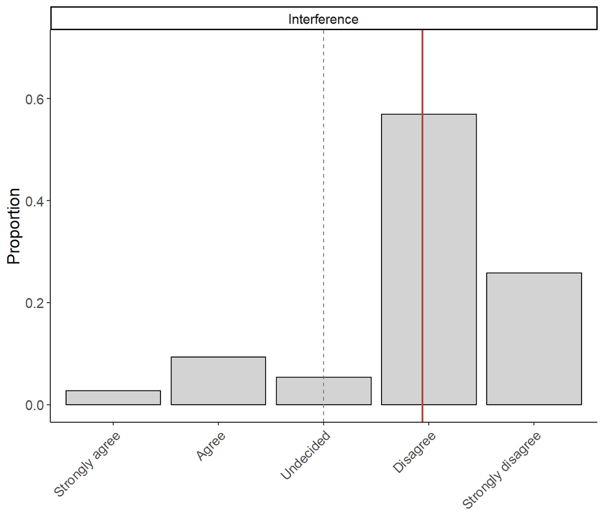

```r
plot_ema_interfere <- data_last %>%
  select(subid, daily_survey_interfere) %>%
  rename(Interference = daily_survey_interfere) %>%
  pivot_longer(Interference, names_to = "measure") %>%
  mutate(value = factor(value, levels = c(-2:2),
                        labels = c("Strongly agree", "Agree", "Undecided", "Disagree", "Strongly disagree"))) %>%
  ggplot(aes(x = value, y = ..prop.., group = measure)) +
  geom_bar(color = "black", fill = "light grey") +
  facet_wrap(~measure) +
  theme_classic() +
  ylim(0, .7) +
  labs(y = "Proportion",
       x = NULL) +
    theme(legend.position = "none",
        text = element_text(size = 14),
        axis.text.x = element_text(angle = 45, hjust = 1)) +
  geom_vline(aes(xintercept = mean(as.numeric(value))), linetype = "solid", size = .705, color = "#b44343") +
  geom_vline(aes(xintercept = "Undecided"), linetype = "dashed", size = .4, color = "#787575")

plot_ema_interfere
```

Uncomment to save figure

```r
# ggsave(plot = plot_ema_interfere, file.choose(), width = 7.5, height = 6, units = "in", device = "png",  dpi = 500)
```

### Dislike Figure

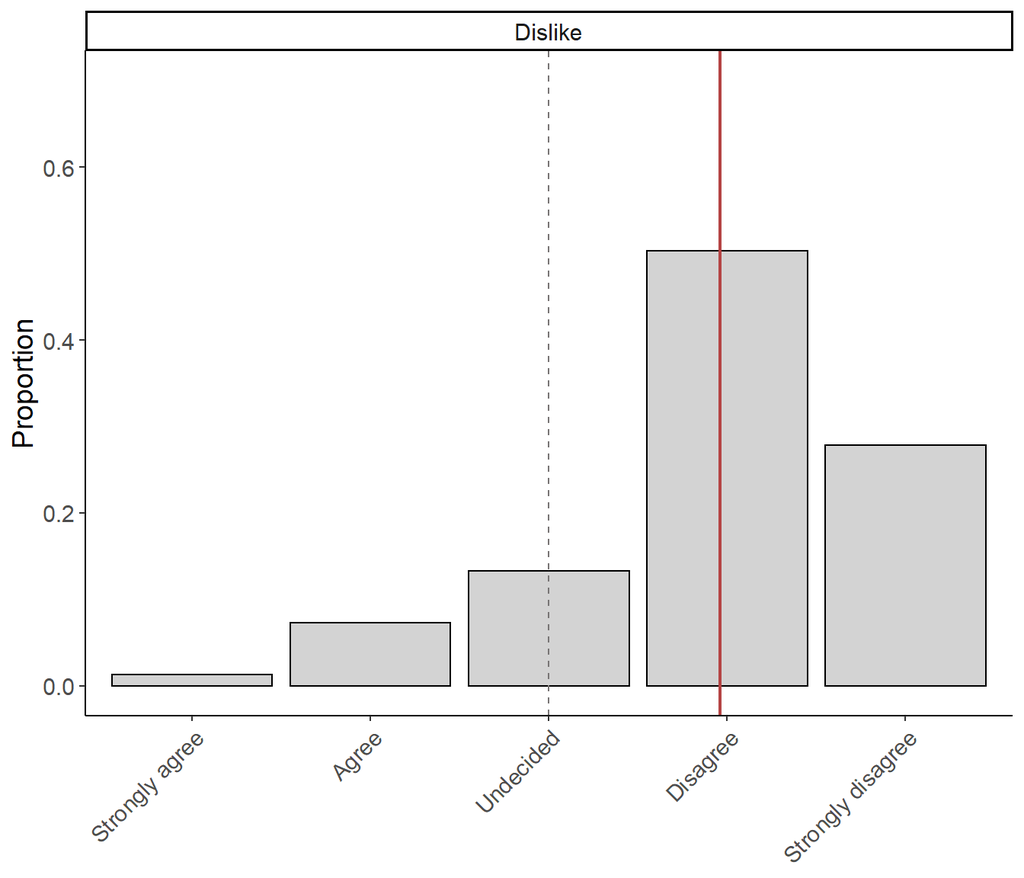

```r
plot_ema_dislike <- data_last %>%
  select(subid, daily_survey_dislike) %>%
  rename(Dislike = daily_survey_dislike) %>%
  pivot_longer(Dislike, names_to = "measure") %>%
  mutate(value = factor(value, levels = c(-2:2),
                        labels = c("Strongly agree", "Agree", "Undecided", "Disagree", "Strongly disagree"))) %>%
  ggplot(aes(x = value, y = ..prop.., group = measure)) +
  geom_bar(color = "black", fill = "light grey") +
  facet_wrap(~measure) +
  theme_classic() +
  ylim(0, .7) +
  labs(y = "Proportion",
       x = NULL) +
    theme(legend.position = "none",
        text = element_text(size = 14),
        axis.text.x = element_text(angle = 45, hjust = 1)) +
  geom_vline(aes(xintercept = mean(as.numeric(value))), linetype = "solid", size = .705, color = "#b44343") +
  geom_vline(aes(xintercept = "Undecided"), linetype = "dashed", size = .4, color = "#787575")

plot_ema_dislike
```

Uncomment to save figure

```r
# ggsave(plot = plot_ema_dislike, file.choose(), width = 7.5, height = 6, units = "in", device = "png",  dpi = 500)
```

### Willingness to Continue for 1 Year Figures

#### 1X Daily

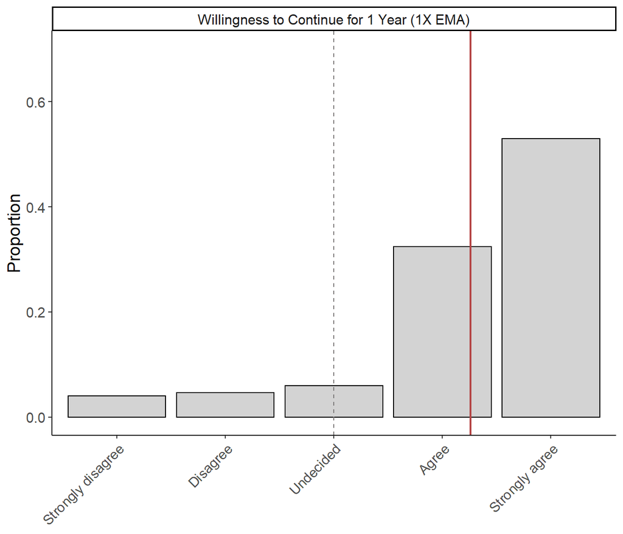

```r
plot_ema_1x <- data_last %>%
  select(subid, daily_survey_1_1year) %>%
  rename(`Willingness to Continue for 1 Year (1X EMA)` = daily_survey_1_1year) %>%
  pivot_longer(`Willingness to Continue for 1 Year (1X EMA)`, names_to = "measure") %>%
  mutate(value = factor(value, levels = c(-2:2),
                        labels = c("Strongly disagree", "Disagree", "Undecided", "Agree", "Strongly agree"))) %>%
  ggplot(aes(x = value, y = ..prop.., group = measure)) +
  geom_bar(color = "black", fill = "light grey") +
  facet_wrap(~measure) +
  theme_classic() +
  ylim(0, .7) +
  labs(y = "Proportion",
       x = NULL) +
    theme(legend.position = "none",
        text = element_text(size = 14),
        axis.text.x = element_text(angle = 45, hjust = 1)) +
  geom_vline(aes(xintercept = mean(as.numeric(value))), linetype = "solid", size = .705, color = "#b44343") +
  geom_vline(aes(xintercept = "Undecided"), linetype = "dashed", size = .4, color = "#787575")

plot_ema_1x
```

Uncomment to save figure

```r
# ggsave(plot = plot_ema_1x, file.choose(), width = 7.5, height = 6, units = "in", device = "png",  dpi = 500)
```

#### 4X Daily

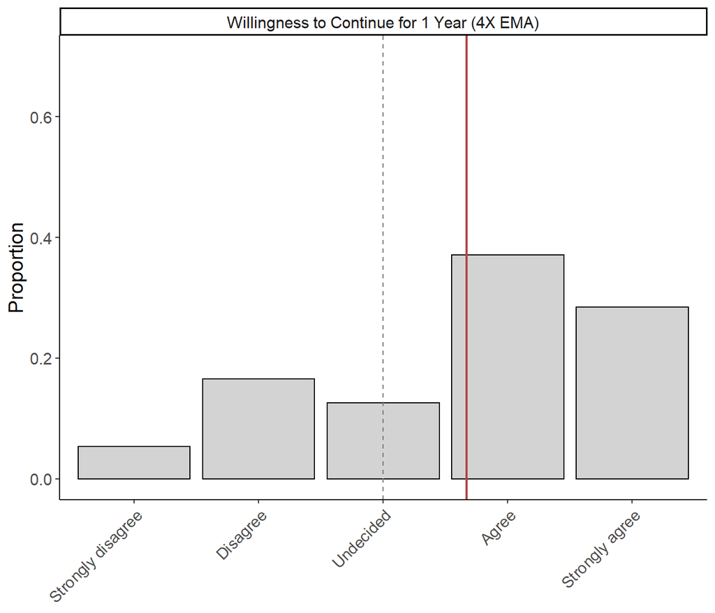

```r
plot_ema_4x <- data_last %>%
  select(subid, daily_survey_4_1year) %>%
  rename(`Willingness to Continue for 1 Year (4X EMA)` = daily_survey_4_1year) %>%
  pivot_longer(`Willingness to Continue for 1 Year (4X EMA)`, names_to = "measure") %>%
  mutate(value = factor(value, levels = c(-2:2),
                        labels = c("Strongly disagree", "Disagree", "Undecided", "Agree", "Strongly agree"))) %>%
  ggplot(aes(x = value, y = ..prop.., group = measure)) +
  geom_bar(color = "black", fill = "light grey") +
  facet_wrap(~measure) +
  theme_classic() +
  ylim(0, .7) +
  labs(y = "Proportion",
       x = NULL) +
    theme(legend.position = "none",
        text = element_text(size = 14),
        axis.text.x = element_text(angle = 45, hjust = 1)) +
  geom_vline(aes(xintercept = mean(as.numeric(value))), linetype = "solid", size = .705, color = "#b44343") +
  geom_vline(aes(xintercept = "Undecided"), linetype = "dashed", size = .4, color = "#787575")

plot_ema_4x
```

Uncomment to save figure

```r
# ggsave(plot = plot_ema_4x, file.choose(), width = 7.5, height = 6, units = "in", device = "png",  dpi = 500)
```

### Compliance Figure

Overall compliance with at least 1 EMA per day by week on study

#### Read in data

```r
ema_m <- vroom(here(path_shared, "ema_morning.csv"), col_types = cols()) %>%
  glimpse()
```

```
## Rows: 11,335
## Columns: 26
## $ response_id <chr> "R_1HkvSG8QkPx8Eu8", "R_2uBUNUJQQ1vkJwa", "R_2fy75pv8FOdwY…
## $ start_date  <dttm> 2017-03-02 15:17:11, 2017-03-03 12:31:39, 2017-03-05 12:3…
## $ end_date    <dttm> 2017-03-02 15:20:19, 2017-03-03 12:35:33, 2017-03-05 12:3…
## $ finished    <dbl> 1, 1, 1, 1, 1, 1, 1, 1, 1, 1, 1, 1, 1, 1, 1, 1, 1, 1, 1, 1…
## $ status      <dbl> 0, 0, 0, 0, 0, 0, 0, 0, 0, 0, 0, 0, 0, 0, 0, 0, 0, 0, 0, 0…
## $ subid       <chr> "001", "001", "001", "001", "001", "001", "001", "001", "0…
## $ utc         <dbl> 1488489431, 1488544299, 1488717171, 1488803446, 1488820692…
## $ send_date   <chr> "02-Mar-17", "03-Mar-17", "05-Mar-17", "06-Mar-17", "06-Ma…
## $ send_time   <dbl> 630, 630, 630, 630, 630, 630, 630, 630, 630, 630, 630, 630…
## $ ema_1       <chr> "No", "No", "No", "No", "No", "No", "No", "No", "No", "No"…
## $ ema_1_1     <chr> NA, NA, NA, NA, NA, NA, NA, NA, NA, NA, NA, NA, NA, NA, NA…
## $ ema_1_2     <chr> NA, NA, NA, NA, NA, NA, NA, NA, NA, NA, NA, NA, NA, NA, NA…
## $ ema_1_3     <chr> NA, NA, NA, NA, NA, NA, NA, NA, NA, NA, NA, NA, NA, NA, NA…
## $ ema_1_4     <chr> NA, NA, NA, NA, NA, NA, NA, NA, NA, NA, NA, NA, NA, NA, NA…
## $ ema_1_5     <chr> NA, NA, NA, NA, NA, NA, NA, NA, NA, NA, NA, NA, NA, NA, NA…
## $ ema_1_6     <chr> NA, NA, NA, NA, NA, NA, NA, NA, NA, NA, NA, NA, NA, NA, NA…
## $ ema_2       <dbl> 4, 2, 2, 2, 3, 1, 3, 2, 4, 3, 1, 2, 1, 2, 4, 3, 2, 9, 2, 1…
## $ ema_3       <dbl> 12, 4, 0, 1, 4, 1, 6, 2, 2, 7, 2, 1, 3, 2, 2, 3, 2, 9, 3, …
## $ ema_4       <dbl> 12, 4, 0, 4, 4, 1, 1, 1, 5, 7, 2, 1, 4, 4, 4, 1, 8, 9, 2, …
## $ ema_5       <dbl> 8, 8, 5, 8, 7, 4, 4, 1, 1, 8, 4, 4, 4, 8, 4, 4, 7, 6, 7, 2…
## $ ema_6       <dbl> 6, 6, 6, 8, 8, 7, 4, 5, 4, 5, 7, 6, 7, 7, 7, 7, 4, 5, 8, 8…
## $ ema_7       <dbl> 8, 3, 3, 8, 7, 8, 4, 4, 6, 7, 4, 4, 4, 5, 7, 5, 8, 5, 4, 4…
## $ ema_8       <dbl> 5, 5, 4, 7, 5, 6, 6, 5, 5, 7, 5, 6, 6, 6, 6, 6, 6, 7, 6, 6…
## $ ema_9       <dbl> 5, 7, 6, 5, 6, 6, 6, 6, 5, 7, 6, 6, 6, 6, 6, 6, 6, 7, 6, 6…
## $ ema_10      <dbl> 4, 4, 4, 4, 5, 5, 5, 4, 6, 5, 5, 5, 5, 5, 6, 5, 6, 6, 5, 5…
## $ ema_type    <chr> "morning", "morning", "morning", "morning", "morning", "mo…
```

```r
ema_l <- vroom(here(path_shared, "ema_later.csv"), col_types = cols()) %>%
  glimpse()
```

```
## Rows: 34,125
## Columns: 23
## $ response_id <chr> "R_DCzfrTzvmKyStd7", "R_2dsYfdSOBQqnVZa", "R_2eXz8kIJqIBmp…
## $ start_date  <dttm> 2017-03-02 20:27:53, 2017-03-03 03:00:38, 2017-03-03 14:1…
## $ end_date    <dttm> 2017-03-02 20:37:43, 2017-03-03 03:02:47, 2017-03-03 14:1…
## $ finished    <dbl> 1, 1, 1, 1, 1, 1, 1, 1, 1, 1, 1, 1, 1, 1, 1, 1, 1, 1, 1, 1…
## $ status      <dbl> 0, 0, 0, 0, 0, 0, 0, 0, 0, 0, 0, 0, 0, 0, 0, 0, 0, 0, 0, 0…
## $ subid       <chr> "001", "001", "001", "001", "001", "001", "001", "001", "0…
## $ utc         <dbl> 1488486473, 1488510038, 1488550270, 1488631626, 1488645112…
## $ send_date   <chr> "02-Mar-17", "02-Mar-17", "03-Mar-17", "03-Mar-17", "04-Ma…
## $ send_time   <dbl> 1342, 1900, 806, 1340, 1030, 849, 1524, 1203, 1323, 1900, …
## $ ema_1       <chr> "No", "No", "No", "No", "No", "No", "No", "No", "No", "No"…
## $ ema_1_1     <chr> NA, NA, NA, NA, NA, NA, NA, NA, NA, NA, NA, NA, NA, NA, NA…
## $ ema_1_2     <chr> NA, NA, NA, NA, NA, NA, NA, NA, NA, NA, NA, NA, NA, NA, NA…
## $ ema_1_3     <chr> NA, NA, NA, NA, NA, NA, NA, NA, NA, NA, NA, NA, NA, NA, NA…
## $ ema_1_4     <chr> NA, NA, NA, NA, NA, NA, NA, NA, NA, NA, NA, NA, NA, NA, NA…
## $ ema_1_5     <chr> NA, NA, NA, NA, NA, NA, NA, NA, NA, NA, NA, NA, NA, NA, NA…
## $ ema_1_6     <chr> NA, NA, NA, NA, NA, NA, NA, NA, NA, NA, NA, NA, NA, NA, NA…
## $ ema_2       <dbl> 5, 1, 1, 3, 3, 1, 3, 4, 2, 2, 3, 3, 2, 3, 2, 3, 4, 1, 1, 2…
## $ ema_3       <dbl> 11, 4, 0, 2, 4, 3, 1, 5, 4, 2, 3, 1, 4, 1, 5, 6, 4, 5, 2, …
## $ ema_4       <dbl> 10, 4, 0, 0, 4, 2, 4, 4, 8, 2, 3, 5, 8, 10, 5, 6, 6, 7, 1,…
## $ ema_5       <dbl> 8, 4, 0, 8, 5, 4, 3, 2, 5, 4, 2, 4, 1, 1, 4, 2, 7, 5, 8, 4…
## $ ema_6       <dbl> 7, 8, 7, 9, 8, 8, 7, 5, 9, 8, 8, 4, 5, 3, 5, 5, 5, 5, 8, 8…
## $ ema_7       <dbl> 7, 7, 8, 6, 7, 7, 8, 6, 5, 7, 4, 5, 5, 3, 5, 4, 5, 8, 5, 6…
## $ ema_type    <chr> "later", "later", "later", "later", "later", "later", "lat…
```

Join morning and evening EMA datasets to get subids and survey start dates

```r
ema <- ema_m %>%
  select(subid, start_date) %>%
  full_join(ema_l %>% select(subid, start_date), by = c("subid", "start_date")) %>%
  mutate(subid = as.numeric(subid),
         start_date = date(start_date)) %>%
  glimpse()
```

```
## Rows: 45,460
## Columns: 2
## $ subid      <dbl> 1, 1, 1, 1, 1, 1, 1, 1, 1, 1, 1, 1, 1, 1, 1, 1, 1, 1, 1, 1,…
## $ start_date <date> 2017-03-02, 2017-03-03, 2017-03-05, 2017-03-06, 2017-03-06…
```

Restrict subids to EMA sample

```r
ema <- ema %>%
  filter(subid %in% data_last$subid) %>%
  glimpse()
```

```
## Rows: 43,567
## Columns: 2
## $ subid      <dbl> 1, 1, 1, 1, 1, 1, 1, 1, 1, 1, 1, 1, 1, 1, 1, 1, 1, 1, 1, 1,…
## $ start_date <date> 2017-03-02, 2017-03-03, 2017-03-05, 2017-03-06, 2017-03-06…
```

Check there are 151 subids

```r
length(unique(ema$subid))
```

```
## [1] 151
```

#### Calculate study dates

Read in visit dates

```r
visit_dates <- vroom(here(path_shared, "visit_dates.csv"), col_types = cols()) %>%
  glimpse()
```

```
## Rows: 207
## Columns: 8
## $ subid       <dbl> 1, 2, 3, 5, 6, 7, 9, 10, 11, 15, 16, 17, 18, 19, 20, 21, 2…
## $ screen      <date> 2017-02-15, 2017-02-17, 2017-03-07, 2017-05-31, 2017-06-0…
## $ intake      <date> 2017-03-01, 2017-03-23, 2017-03-21, 2017-06-19, 2017-06-1…
## $ start_study <date> 2017-03-02, 2017-03-24, 2017-03-22, 2017-06-20, 2017-06-1…
## $ followup_1  <date> 2017-03-31, 2017-04-21, 2017-04-26, 2017-07-19, 2017-07-1…
## $ followup_2  <date> 2017-05-01, 2017-05-22, 2017-05-24, 2017-08-21, 2017-08-1…
## $ end_study   <date> 2017-05-31, 2017-06-16, 2017-06-20, 2017-09-18, 2017-09-1…
## $ final_visit <date> 2017-06-05, 2017-06-16, 2017-06-21, 2017-09-22, 2017-09-1…
```

Get all study days for each subid

```r
# function to map over
get_study_days <- function(the_subid, dates) {
  start_study <- dates %>% filter(subid == the_subid) %>% pull(start_study)
  end_study <- dates %>% filter(subid == the_subid) %>% pull(end_study)
  study_days <- tibble(subid = the_subid, study_day = seq(start_study, end_study - days(1), by = "day"))
  return(study_days)
}

subids <- unique(ema$subid)

study_dates <- subids %>%
  map_dfr(~get_study_days(.x, visit_dates)) %>%
  glimpse()
```

```
## Rows: 12,863
## Columns: 2
## $ subid     <dbl> 1, 1, 1, 1, 1, 1, 1, 1, 1, 1, 1, 1, 1, 1, 1, 1, 1, 1, 1, 1, …
## $ study_day <date> 2017-03-02, 2017-03-03, 2017-03-04, 2017-03-05, 2017-03-06,…
```

#### Calculate compliance with 1 EMA per day

Count EMAs per study day

```r
# count EMAs per day
ema_1_count <- ema %>%
  count(subid, start_date) %>%
  mutate(n = if_else(n > 1, 1, as.numeric(n)))

# left join with study dates
ema_1_study_dates <- study_dates %>%
  left_join(ema_1_count, by = c("subid", "study_day" = "start_date")) %>%
  mutate(n = if_else(is.na(n), 0, n)) %>%
  mutate(n_prompts = 1) %>%
  glimpse()
```

```
## Rows: 12,863
## Columns: 4
## $ subid     <dbl> 1, 1, 1, 1, 1, 1, 1, 1, 1, 1, 1, 1, 1, 1, 1, 1, 1, 1, 1, 1, …
## $ study_day <date> 2017-03-02, 2017-03-03, 2017-03-04, 2017-03-05, 2017-03-06,…
## $ n         <dbl> 1, 1, 1, 1, 1, 1, 1, 1, 1, 1, 1, 1, 1, 1, 1, 1, 1, 1, 1, 1, …
## $ n_prompts <dbl> 1, 1, 1, 1, 1, 1, 1, 1, 1, 1, 1, 1, 1, 1, 1, 1, 1, 1, 1, 1, …
```

calculate mean compliance

```r
mean_ema_1 <- ema_1_study_dates %>%
  summarize(n_total = sum(n), prompt_total = sum(n_prompts)) %>%
  mutate(mean = n_total/prompt_total)
```

mean compliance for one daily survey is 0.9547539

Compliance over time

Slice into 7 day bins

```r
ema_1_study_weeks <- ema_1_study_dates %>%
  group_by(subid) %>%
  slice(1:7) %>%
  mutate(week = 1) %>%
  bind_rows(ema_1_study_dates %>%
    group_by(subid) %>%
    slice(8:14) %>%
    mutate(week = 2)) %>%
  bind_rows(ema_1_study_dates %>%
    group_by(subid) %>%
    slice(15:21) %>%
    mutate(week = 3)) %>%
  bind_rows(ema_1_study_dates %>%
    group_by(subid) %>%
    slice(22:28) %>%
    mutate(week = 4)) %>%
  bind_rows(ema_1_study_dates %>%
    group_by(subid) %>%
    slice(29:35) %>%
    mutate(week = 5)) %>%
  bind_rows(ema_1_study_dates %>%
    group_by(subid) %>%
    slice(36:42) %>%
    mutate(week = 6)) %>%
  bind_rows(ema_1_study_dates %>%
    group_by(subid) %>%
    slice(43:49) %>%
    mutate(week = 7)) %>%
  bind_rows(ema_1_study_dates %>%
    group_by(subid) %>%
    slice(50:56) %>%
    mutate(week = 8)) %>%
  bind_rows(ema_1_study_dates %>%
    group_by(subid) %>%
    slice(57:63) %>%
    mutate(week = 9)) %>%
  bind_rows(ema_1_study_dates %>%
    group_by(subid) %>%
    slice(64:70) %>%
    mutate(week = 10)) %>%
  bind_rows(ema_1_study_dates %>%
    group_by(subid) %>%
    slice(71:77) %>%
    mutate(week = 11)) %>%
  bind_rows(ema_1_study_dates %>%
    group_by(subid) %>%
    slice(78:84) %>%
    mutate(week = 12)) %>%
  ungroup()
```

Get individual compliance scores

```r
ema_1_week_compliance <- ema_1_study_weeks %>%
  mutate(n = if_else(n > 1, 1, n),
         n_prompts = 1) %>%
  group_by(subid, week) %>%
  summarize(sum_n = sum(n), sum_prompts = sum(n_prompts), .groups = "rowwise") %>%
  mutate(compliance = sum_n/sum_prompts) %>%
  ungroup() %>%
  glimpse()
```

```
## Rows: 1,746
## Columns: 5
## $ subid       <dbl> 1, 1, 1, 1, 1, 1, 1, 1, 1, 1, 1, 1, 2, 2, 2, 2, 2, 2, 2, 2…
## $ week        <dbl> 1, 2, 3, 4, 5, 6, 7, 8, 9, 10, 11, 12, 1, 2, 3, 4, 5, 6, 7…
## $ sum_n       <dbl> 7, 7, 7, 7, 7, 7, 7, 0, 1, 6, 6, 7, 7, 7, 7, 7, 7, 7, 7, 6…
## $ sum_prompts <dbl> 7, 7, 7, 7, 7, 7, 7, 7, 7, 7, 7, 7, 7, 7, 7, 7, 7, 7, 7, 7…
## $ compliance  <dbl> 1.0000000, 1.0000000, 1.0000000, 1.0000000, 1.0000000, 1.0…
```

Summarize total compliance

```r
ema_1_week_compliance %>%
  group_by(week) %>%
  summarize(mean_compliance = mean(compliance))
```

```
## # A tibble: 12 × 2
##     week mean_compliance
##    <dbl>           <dbl>
##  1     1           0.989
##  2     2           0.991
##  3     3           0.974
##  4     4           0.960
##  5     5           0.967
##  6     6           0.965
##  7     7           0.940
##  8     8           0.917
##  9     9           0.937
## 10    10           0.955
## 11    11           0.925
## 12    12           0.933
```

#### Calculate compliance for 4x daily EMA

Overall proportion of EMAs completed while on study

Count EMAs per study day

```r
# count EMAs per day
ema_4_count <- ema %>%
  count(subid, start_date) %>%
  mutate(n = if_else(n > 4, 4, as.numeric(n)))

# left join with study dates
ema_4_study_dates <- study_dates %>%
  left_join(ema_4_count, by = c("subid", "study_day" = "start_date")) %>%
  mutate(n = if_else(is.na(n), 0, n)) %>%
  mutate(n_prompts = 4) %>%
  glimpse()
```

```
## Rows: 12,863
## Columns: 4
## $ subid     <dbl> 1, 1, 1, 1, 1, 1, 1, 1, 1, 1, 1, 1, 1, 1, 1, 1, 1, 1, 1, 1, …
## $ study_day <date> 2017-03-02, 2017-03-03, 2017-03-04, 2017-03-05, 2017-03-06,…
## $ n         <dbl> 2, 3, 2, 3, 3, 2, 4, 1, 4, 4, 4, 1, 3, 4, 3, 2, 3, 4, 3, 4, …
## $ n_prompts <dbl> 4, 4, 4, 4, 4, 4, 4, 4, 4, 4, 4, 4, 4, 4, 4, 4, 4, 4, 4, 4, …
```

calculate mean compliance

```r
mean_ema_4 <- ema_4_study_dates %>%
  summarize(n_total = sum(n), prompt_total = sum(n_prompts)) %>%
  mutate(mean = n_total/prompt_total)
```

compliance = 0.7918837

avg emas completed daily = 3.1675348

Compliance over time

Slice into 7 day bins

```r
ema_4_study_weeks <- ema_4_study_dates %>%
  group_by(subid) %>%
  slice(1:7) %>%
  mutate(week = 1) %>%
  bind_rows(ema_4_study_dates %>%
    group_by(subid) %>%
    slice(8:14) %>%
    mutate(week = 2)) %>%
  bind_rows(ema_4_study_dates %>%
    group_by(subid) %>%
    slice(15:21) %>%
    mutate(week = 3)) %>%
  bind_rows(ema_4_study_dates %>%
    group_by(subid) %>%
    slice(22:28) %>%
    mutate(week = 4)) %>%
  bind_rows(ema_4_study_dates %>%
    group_by(subid) %>%
    slice(29:35) %>%
    mutate(week = 5)) %>%
  bind_rows(ema_4_study_dates %>%
    group_by(subid) %>%
    slice(36:42) %>%
    mutate(week = 6)) %>%
  bind_rows(ema_4_study_dates %>%
    group_by(subid) %>%
    slice(43:49) %>%
    mutate(week = 7)) %>%
  bind_rows(ema_4_study_dates %>%
    group_by(subid) %>%
    slice(50:56) %>%
    mutate(week = 8)) %>%
  bind_rows(ema_4_study_dates %>%
    group_by(subid) %>%
    slice(57:63) %>%
    mutate(week = 9)) %>%
  bind_rows(ema_4_study_dates %>%
    group_by(subid) %>%
    slice(64:70) %>%
    mutate(week = 10)) %>%
  bind_rows(ema_4_study_dates %>%
    group_by(subid) %>%
    slice(71:77) %>%
    mutate(week = 11)) %>%
  bind_rows(ema_4_study_dates %>%
    group_by(subid) %>%
    slice(78:84) %>%
    mutate(week = 12)) %>%
  ungroup()
```

Get individual compliance scores - N EMAs/possible EMAs

```r
ema_4_week_compliance <- ema_4_study_weeks %>%
  group_by(subid, week) %>%
  summarize(sum_n = sum(n), sum_prompts = sum(n_prompts), .groups = "rowwise") %>%
  mutate(compliance = sum_n/sum_prompts) %>%
  ungroup() %>%
  glimpse()
```

```
## Rows: 1,746
## Columns: 5
## $ subid       <dbl> 1, 1, 1, 1, 1, 1, 1, 1, 1, 1, 1, 1, 2, 2, 2, 2, 2, 2, 2, 2…
## $ week        <dbl> 1, 2, 3, 4, 5, 6, 7, 8, 9, 10, 11, 12, 1, 2, 3, 4, 5, 6, 7…
## $ sum_n       <dbl> 19, 21, 23, 23, 20, 22, 18, 0, 3, 8, 10, 12, 27, 27, 22, 2…
## $ sum_prompts <dbl> 28, 28, 28, 28, 28, 28, 28, 28, 28, 28, 28, 28, 28, 28, 28…
## $ compliance  <dbl> 0.6785714, 0.7500000, 0.8214286, 0.8214286, 0.7142857, 0.7…
```

Summarize total compliance

```r
ema_4_week_compliance %>%
  group_by(week) %>%
  summarize(mean_compliance = mean(compliance))
```

```
## # A tibble: 12 × 2
##     week mean_compliance
##    <dbl>           <dbl>
##  1     1           0.851
##  2     2           0.868
##  3     3           0.831
##  4     4           0.803
##  5     5           0.801
##  6     6           0.792
##  7     7           0.765
##  8     8           0.759
##  9     9           0.755
## 10    10           0.781
## 11    11           0.753
## 12    12           0.753
```

#### Plot compliance

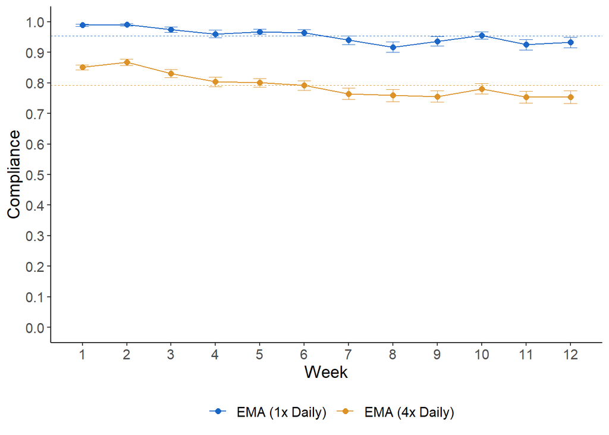

```r
week_compliance_all <- ema_4_week_compliance %>%
              group_by(week) %>%
              summarize(mean_compliance = mean(compliance),
                        n = n(),
                        sd = sd(compliance)) %>%
              mutate(se = sd/sqrt(n),
                     signal = "EMA (4x Daily)") %>%
  bind_rows(ema_1_week_compliance %>%
              group_by(week) %>%
              summarize(mean_compliance = mean(compliance),
                        n = n(),
                        sd = sd(compliance)) %>%
              mutate(se = sd/sqrt(n),
                     signal = "EMA (1x Daily)"))

plot_weekly_compliance <- week_compliance_all %>%
  mutate(signal = factor(signal, levels = c("EMA (1x Daily)", "EMA (4x Daily)"))) %>%
  group_by(week, signal) %>%
  ggplot(aes(x = week, y = mean_compliance, group = signal, color = signal)) +
  geom_point(size = 2) +
  geom_line() +
  geom_errorbar(aes(ymin = mean_compliance - se, ymax = mean_compliance + se),
                width = .3, size = .3) +
  scale_color_manual(values = c("#1966C7", "#DC9227")) +
  scale_x_continuous(name = "Week",
                     breaks = seq(1, 12, 1)) +
  scale_y_continuous(name = "Compliance",
                     breaks = seq(0, 1, .1),
                     limits = c(0, 1)) +
  geom_hline(aes(yintercept = mean_compliance), week_compliance_all %>%
               group_by(signal) %>%
               summarize(mean_compliance = mean(mean_compliance)),
             linetype = "dashed", size = .3, color = c("#1966C7", "#DC9227")) +
  theme_classic() +
  theme(legend.title = element_blank(),
        text = element_text(size = 14),
        legend.position = "bottom")

plot_weekly_compliance
```

Uncomment to save figure

```r
# ggsave(plot = plot_weekly_compliance, file.choose(), width = 7.5, height = 6, units = "in", device = "png",  dpi = 500)
```